# Part I - House Rent Prediction

## Introduction

This project explores a housing dataset that contains approximately 4700 attributes of house/apartments/flats listing. My aim is to find out what variables has direct impact on the rent increase of house/apartments/flats listings.

## Preliminary Wrangling

```python
# import all packages and set plots to be embedded inline
import numpy as np
import pandas as pd
import matplotlib.pyplot as plt
import seaborn as sb

%matplotlib inline
```

```python
# load in the dataset into a pandas dataframe.
house_rent = pd.read_csv('House_Rent_Dataset.csv', usecols = ['BHK','Rent', 'Size', 'Area Type', 'City',
                                                        'Furnishing Status', 'Tenant Preferred', 'Bathroom', 'Point of Contact'])
```

#### columns:

- BHK: Number of Bedrooms, 1 Hall, 1 Kitchen.
- Rent: Rent of the Houses/Apartments/Flats.
- Size: Size of the Houses/Apartments/Flats in Square Feet.
- Area Type: Size of the Houses/Apartments/Flats calculated on either Super Area or Carpet Area or Build Area.
- City: City where the Houses/Apartments/Flats are Located.
- Furnishing Status: Furnishing Status of the Houses/Apartments/Flats, either it is Furnished or Semi-Furnished or Unfurnished.
- Tenant Preferred: Type of Tenant Preferred by the Owner or Agent.
- Bathroom: Number of Bathrooms.
- Point of Contact: Whom should you contact for more information regarding the Houses/Apartments/Flats.

```python
# high-level overview of data shape and composition
print(house_rent.shape)
print(house_rent.dtypes)
print(house_rent.head(10))
print(house_rent.info())
```

```
(4746, 9)
BHK                   int64
Rent                  int64
Size                  int64
Area Type            object
City                 object
Furnishing Status    object
Tenant Preferred     object
Bathroom              int64
Point of Contact     object
dtype: object
   BHK   Rent  Size    Area Type     City Furnishing Status  Tenant Preferred  \
0    2  10000  1100   Super Area  Kolkata       Unfurnished  Bachelors/Family
1    2  20000   800   Super Area  Kolkata    Semi-Furnished  Bachelors/Family
2    2  17000  1000   Super Area  Kolkata    Semi-Furnished  Bachelors/Family
3    2  10000   800   Super Area  Kolkata       Unfurnished  Bachelors/Family
4    2   7500   850  Carpet Area  Kolkata       Unfurnished         Bachelors
5    2   7000   600   Super Area  Kolkata       Unfurnished  Bachelors/Family
6    2  10000   700   Super Area  Kolkata       Unfurnished         Bachelors
7    1   5000   250   Super Area  Kolkata       Unfurnished         Bachelors
8    2  26000   800  Carpet Area  Kolkata       Unfurnished         Bachelors
9    2  10000  1000  Carpet Area  Kolkata    Semi-Furnished  Bachelors/Family

   Bathroom Point of Contact
0         2    Contact Owner
1         1    Contact Owner
2         1    Contact Owner
3         1    Contact Owner
4         1    Contact Owner
5         2    Contact Owner
6         2    Contact Agent
7         1    Contact Agent
8         2    Contact Agent
9         2    Contact Owner
<class 'pandas.core.frame.DataFrame'>
RangeIndex: 4746 entries, 0 to 4745
Data columns (total 9 columns):
 #   Column             Non-Null Count  Dtype
---  ------             --------------  -----
 0   BHK                4746 non-null   int64
 1   Rent               4746 non-null   int64
 2   Size               4746 non-null   int64
 3   Area Type          4746 non-null   object
 4   City               4746 non-null   object
 5   Furnishing Status  4746 non-null   object
 6   Tenant Preferred   4746 non-null   object
 7   Bathroom           4746 non-null   int64
 8   Point of Contact   4746 non-null   object
dtypes: int64(4), object(5)
memory usage: 333.8+ KB
None
```

```python
# convert all columns name to lower case
house_rent.columns = house_rent.columns.str.lower()
house_rent.columns
```

```
Index(['bhk', 'rent', 'size', 'area type', 'city', 'furnishing status',
       'tenant preferred', 'bathroom', 'point of contact'],
      dtype='object')
```

```python
house_rent.bhk.value_counts()
```

```
2    2265
1    1167
3    1098
4     189
5      19
6       8
Name: bhk, dtype: int64
```

```python
house_rent.bathroom.value_counts()
```

```
2     2291
1     1474
3      749
4      156
5       60
6       12
7        3
10       1
Name: bathroom, dtype: int64
```

```python
house_rent[house_rent.bathroom >= 7]
```

|  | bhk | rent | size | area type | city | furnishing status | tenant preferred | bathroom | point of contact |
| --- | --- | --- | --- | --- | --- | --- | --- | --- | --- |
| 2846 | 4 | 150000 | 4000 | Carpet Area | Delhi | Semi-Furnished | Bachelors | 7 | Contact Agent |
| 4185 | 1 | 200000 | 8000 | Super Area | Hyderabad | Unfurnished | Bachelors/Family | 10 | Contact Owner |
| 4350 | 6 | 60000 | 2800 | Super Area | Hyderabad | Furnished | Bachelors/Family | 7 | Contact Owner |
| 4518 | 6 | 35000 | 3400 | Super Area | Hyderabad | Unfurnished | Bachelors/Family | 7 | Contact Owner |

```python
# getting the index of rows to drop
bathroom_err = house_rent[house_rent.bathroom >= 7].index
```

```python
# drop
house_rent = house_rent.drop(bathroom_err)
```

This records are not consistent when compared by bhk, rent and bathroom, so we have to drop record of where bathroom is >= 7.

```python
# convert cut, color, and clarity into ordered categorical types
ordinal_var_dict = {'bhk': [1, 2, 3, 4, 5, 6],
                    'bathroom': [1, 2, 3, 4, 5, 6]}

for var in ordinal_var_dict:
    ordered_var = pd.api.types.CategoricalDtype(ordered = True,
                                                categories = ordinal_var_dict[var])
    house_rent[var] = house_rent[var].astype(ordered_var)
```

```python
# remove spaces in columns name
house_rent.columns = house_rent.columns.str.replace(" ", "_")
```

```python
# checking datatypes
house_rent.dtypes
```

```
bhk                  category
rent                    int64
size                    int64
area_type              object
city                   object
furnishing_status      object
tenant_preferred       object
bathroom             category
point_of_contact       object
dtype: object
```

```python
# descriptive statistics for numeric variables
print(house_rent.describe())
```

```
               rent         size
count  4.742000e+03  4742.000000
mean   3.492913e+04   964.468790
std    7.808387e+04   623.069125
min    1.200000e+03    10.000000
25%    1.000000e+04   550.000000
50%    1.600000e+04   850.000000
75%    3.297500e+04  1200.000000
max    3.500000e+06  7000.000000
```

```python
house_rent.info()
```

```
<class 'pandas.core.frame.DataFrame'>
Int64Index: 4742 entries, 0 to 4745
Data columns (total 9 columns):
 #   Column             Non-Null Count  Dtype
---  ------             --------------  -----
 0   bhk                4742 non-null   category
 1   rent               4742 non-null   int64
 2   size               4742 non-null   int64
 3   area_type          4742 non-null   object
 4   city               4742 non-null   object
 5   furnishing_status  4742 non-null   object
 6   tenant_preferred   4742 non-null   object
 7   bathroom           4742 non-null   category
 8   point_of_contact   4742 non-null   object
dtypes: category(2), int64(2), object(5)
memory usage: 306.1+ KB
```

### What is the structure of your dataset?

In this Dataset, we have information on 4746 Houses/Apartments/Flats Available for Rent with 9 different parameters like bhk, rent, size, area_type, city, furnishing_status, type of tenant_preferred, No. of bathrooms, point_of_Contact. Most parameters are object type but variables rent and size are datatype int while bhk and bathroom are ordered factor variables with the following levels.

(small) ——> (big)  
bhk: 1, 2, 3, 4, 5, 6  
bathroom: 1, 2, 3, 4, 5, 6

### What is/are the main feature(s) of interest in your dataset?

For this project i'm interested in figuring out what features of the dataset interacts best with rent, in order to identify the primary and secondary cause for price. I'm also interested in figuring out what the most common bhk type.

### What features in the dataset do you think will help support your investigation into your feature(s) of interest?

From this dataset, i expect Size to have the strongest effect on the rent fees. Some other variable parameters might have an effect on rent, though to a much smaller degree than the main effect of size.

## Univariate Exploration

**I will begin by looking at the distribution of the main variable of interest: rent.**

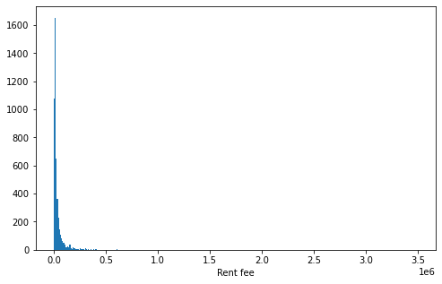

```python
# start with a standard-scaled plot
binsize = 10000
bins = np.arange(0, house_rent['rent'].max()+binsize, binsize)

plt.figure(figsize=[8, 5])
plt.hist(data = house_rent, x = 'rent', bins = bins)
plt.xlabel('Rent fee')
plt.show()
```

**identifying and dropping the outliers**

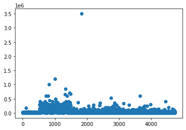

```python
# rent vs index scatter plot
plt.scatter(data = house_rent, y = 'rent', x= house_rent.index)
```

There is an outlier of 3.5 Million in rent.  
Lets apply the rule of thumb to identify further outliers.

```python
house_rent.rent.describe()
```

```
count    4.742000e+03
mean     3.492913e+04
std      7.808387e+04
min      1.200000e+03
25%      1.000000e+04
50%      1.600000e+04
75%      3.297500e+04
max      3.500000e+06
Name: rent, dtype: float64
```

Any points from the rent above 67500 is an outlier. clearly, we have an outlier in the graph, we have to delete them.

```python
# identifying outliers
house_rent[house_rent['rent'] > 67500]
```

|  | bhk | rent | size | area_type | city | furnishing_status | tenant_preferred | bathroom | point_of_contact |
| --- | --- | --- | --- | --- | --- | --- | --- | --- | --- |
| 104 | 2 | 180000 | 950 | Carpet Area | Kolkata | Unfurnished | Bachelors/Family | 2 | Contact Owner |
| 525 | 2 | 70000 | 750 | Carpet Area | Mumbai | Furnished | Bachelors/Family | 2 | Contact Agent |
| 527 | 3 | 75000 | 1100 | Carpet Area | Mumbai | Unfurnished | Family | 3 | Contact Agent |
| 530 | 2 | 160000 | 800 | Carpet Area | Mumbai | Unfurnished | Bachelors/Family | 2 | Contact Owner |
| 531 | 4 | 300000 | 1600 | Carpet Area | Mumbai | Semi-Furnished | Bachelors/Family | 5 | Contact Agent |
| ... | ... | ... | ... | ... | ... | ... | ... | ... | ... |
| 4523 | 3 | 70000 | 2780 | Super Area | Hyderabad | Semi-Furnished | Bachelors/Family | 3 | Contact Agent |
| 4543 | 4 | 200000 | 4761 | Carpet Area | Hyderabad | Semi-Furnished | Bachelors | 6 | Contact Owner |
| 4648 | 6 | 80000 | 4500 | Super Area | Hyderabad | Semi-Furnished | Bachelors/Family | 6 | Contact Owner |
| 4669 | 4 | 140000 | 3789 | Carpet Area | Hyderabad | Semi-Furnished | Family | 5 | Contact Agent |
| 4716 | 4 | 110000 | 3250 | Carpet Area | Hyderabad | Semi-Furnished | Bachelors/Family | 5 | Contact Owner |

518 rows × 9 columns

We need to drop the above record because of the inconsistencie in them.

```python
outliers = house_rent[house_rent['rent'] > 67500].index
```

```python
# drop the outliers
house_rent.drop(outliers, inplace=True)
```

The graph above is not giving us enough information, we will be making use of axis transformation to get better insights.

```python
house_rent['rent'].describe()
```

```
count     4224.000000
mean     19272.803741
std      13812.346924
min       1200.000000
25%       9500.000000
50%      15000.000000
75%      25000.000000
max      67000.000000
Name: rent, dtype: float64
```

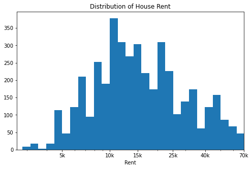

```python
# plotting rent on a standard scale
log_binsize = 0.05
#bins = np.arange(0, house_rent['rent'].max()+binsize, binsize)
bins = 10 ** np.arange(2.4, np.log10(house_rent['rent'].max())+log_binsize, log_binsize)

plt.figure(figsize=[8, 5])
plt.hist(data = house_rent, x = 'rent', bins = bins)
plt.xscale('log')
plt.xlim([2600, 7e4])
plt.xticks([5e3, 1e4, 1.5e4, 2.5e4, 4e4, 7e4], ['5k', '10k', '15k', '25k', '40k', '70k'])
plt.title('Distribution of House Rent')
plt.xlabel('Rent')
plt.show()
```

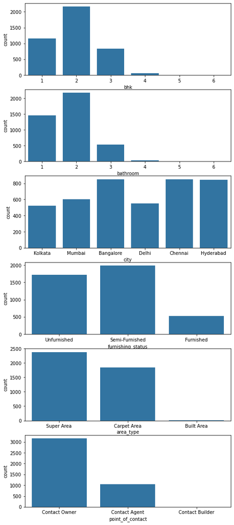

```python
# let's plot all three (bhk, bathroom and city) together to get an idea of each ordinal variable's distribution.

fig, ax = plt.subplots(nrows=6, figsize = [8,20])

default_color = sb.color_palette()[0]
sb.countplot(data = house_rent, x = 'bhk', color = default_color, ax = ax[0])
sb.countplot(data = house_rent, x = 'bathroom', color = default_color, ax = ax[1])
sb.countplot(data = house_rent, x = 'city', color = default_color, ax = ax[2])
sb.countplot(data = house_rent, x = 'furnishing_status', color = default_color, ax = ax[3])
sb.countplot(data = house_rent, x = 'area_type', color = default_color, ax = ax[4])
sb.countplot(data = house_rent, x = 'point_of_contact', color = default_color, ax = ax[5])

plt.show()
```

The distribution of 'bhk' and 'bathroom' are similar to esch other, the number of bedrooms in a house/apartment corresponds to the number of bathrooms too.  
Also, most house/apartment are 1,2 and 3 bedrooms with 2 bedrooms the most popular amongst them. very few houses/apartments has 4 and above rooms/bathrooms. There is balaced distribution of number of houses/apartments across the city, with most of them unfurnished or semi-furnished, very few are furnished. Almost all houses/apartments are in Super and Carpet Area. Finally, the major point of contact is through the owner of the property.

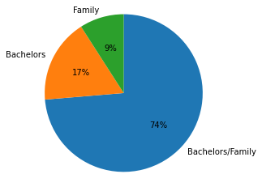

```python
# pie plot of tenant_preferred
house_rent.tenant_preferred.value_counts()
tp_sorted_counts = house_rent.tenant_preferred.value_counts()

plt.pie(tp_sorted_counts, labels = tp_sorted_counts.index, startangle = 90, counterclock = False, autopct='%1.0f%%');
plt.axis('square');
```

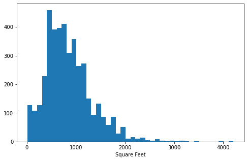

```python
# lets plot for the size of the property in cm cube
binsize = 100
bins = np.arange(10, house_rent['size'].max()+binsize, binsize)

plt.figure(figsize=[8, 5])
plt.hist(data = house_rent, x = 'size', bins = bins)
plt.xlabel('Square Feet')
plt.show()
```

```python
house_rent['size'].describe()
```

```
count    4224.000000
mean      870.724195
std       483.423454
min        10.000000
25%       520.000000
50%       800.000000
75%      1100.000000
max      4200.000000
Name: size, dtype: float64
```

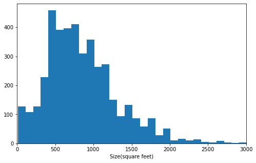

```python
binsize = 100
bins = np.arange(10, house_rent['size'].max()+binsize, binsize)

plt.figure(figsize=[8, 5])
plt.hist(data = house_rent, x = 'size', bins = bins)
plt.xlabel('Size(square feet)')
# Set the upper and lower bounds of the bins that are displayed in the plot
plt.xlim((0,3000));
plt.show()
```

From the histogram chart, size appears to be right skewed. Majority of the data are located at the low size range, with a steady decline after 500 sqft.

### Discuss the distribution(s) of your variable(s) of interest. Were there any unusual points? Did you need to perform any transformations?

Size distribution looked right skewed, with majority of it data located at the lower end of size range, meaning average houses are below 1500(square feet) while those above 1500 (square feet) are few. Also, there appears to be a similar reaction between the number of bhk and bathroom.

### Of the features you investigated, were there any unusual distributions? Did you perform any operations on the data to tidy, adjust, or change the form of the data? If so, why did you do this?

When investing the dataset, a number of oufliers were found in the rent variable. For safety, all of these points were removed from the dataset to move forwards

## Bivariate Exploration

**Firstly, lets look at the relationship between the rent and size of the property**

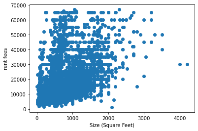

```python
# Scatter plot graph for rent price and size
plt.scatter(data = house_rent, x = 'size', y = 'rent');
plt.xlabel('Size (Square Feet)')
plt.ylabel('rent fees')
```

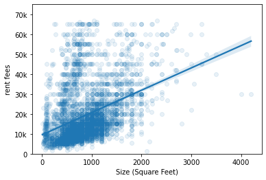

```python
# a regplot of rent and size
sb.regplot(data = house_rent, x = 'size', y = 'rent', scatter_kws={'alpha':1/10});
plt.xlabel('Size (Square Feet)')
plt.ylabel('rent fees')
plt.yticks([0, 1e4, 2e4, 3e4, 4e4, 5e4, 6e4, 7e4], ['0', '10k', '20k', '30k', '40k', '50k', '60k', '70k'])
plt.ylim((0,75000));
```

[output not shown]

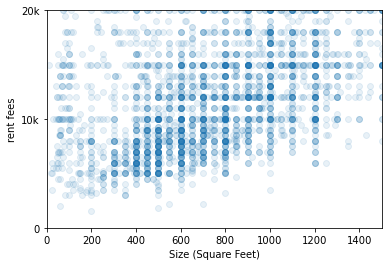

```python
# scatter plot to reveal non-linear distribution
plt.scatter(data = house_rent, x = 'size', y = 'rent', alpha=1/10);
plt.xlabel('Size (Square Feet)')
plt.ylabel('rent fees')
plt.yticks([0, 1e4, 2e4, 3e5, 4e4, 5e4, 6e4, 7e4], ['0', '10k', '20k', '30k', '40k', '50k', '60k', '70k'])
plt.ylim((0,20000))
plt.xlim(0,1500)
```

The relationship between the two variables appears positive, the higher values of the x-axis, the more the y-axis increases  
Since a higher density results in a darker color, the peak of the distribution appears to be below rent of 20000 and size 1500. Interestingly, some points have increased rent without increase in size, this will be looked into in the mutivariate part of analysis.

**Now, let's look at how the qualitative variables reacts to the rent price. and size.**  
We need to find out what variable acts as a secondary means or influence in price?

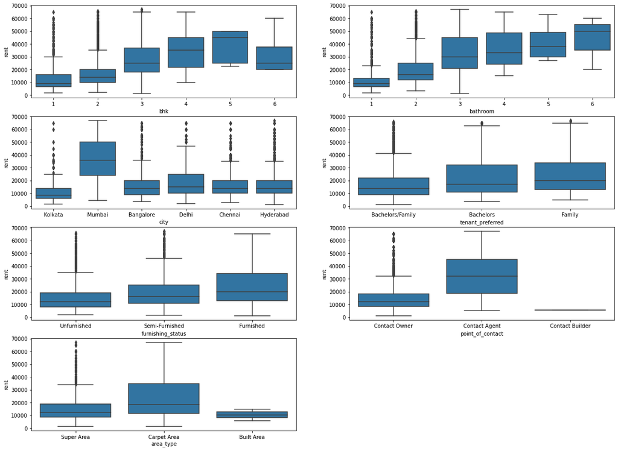

```python
# Plotting boxplot of rent and qualitative variables
def var_boxplot(var):
    column = var
    plt.figure(figsize = [20, 15])
    base_color = sb.color_palette()[0]

    # LEFT plot: boxplot plot
    plt.subplot(4, 2, 1)
    #Let's return the axes object
    ax1 = sb.boxplot(data=house_rent, x='bhk', y=column, color=base_color);

    # RIGHT plot: box plot
    plt.subplot(4, 2, 2)
    sb.boxplot(data=house_rent, x='bathroom', y=column, color=base_color);
    plt.ylim(ax1.get_ylim()) # set y-axis limits to be same as left plot

    # LEFT plot: boxplot plot
    plt.subplot(4, 2, 3)
    #Let's return the axes object
    ax1 = sb.boxplot(data=house_rent, x='city', y=column, color=base_color);

    # RIGHT plot: box plot
    plt.subplot(4, 2, 4)
    sb.boxplot(data=house_rent, x='tenant_preferred', y=column, color=base_color);
    plt.ylim(ax1.get_ylim()) # set y-axis limits to be same as left plot

    # LEFT plot: boxplot plot
    plt.subplot(4, 2, 5)
    #Let's return the axes object
    ax1 = sb.boxplot(data=house_rent, x='furnishing_status', y=column, color=base_color);

    # RIGHT plot: box plot
    plt.subplot(4, 2, 6)
    sb.boxplot(data=house_rent, x='point_of_contact', y=column, color=base_color)
    plt.ylim(ax1.get_ylim()) # set y-axis limits to be same as left plot

    # LEFT plot: boxplot plot
    plt.subplot(4, 2, 7)
    #Let's return the axes object
    ax1 = sb.boxplot(data=house_rent, x='area_type', y=column, color=base_color)

var_boxplot('rent')
```

**Since we know that price reacts best to rent, lets find out what variable might react to size best?**

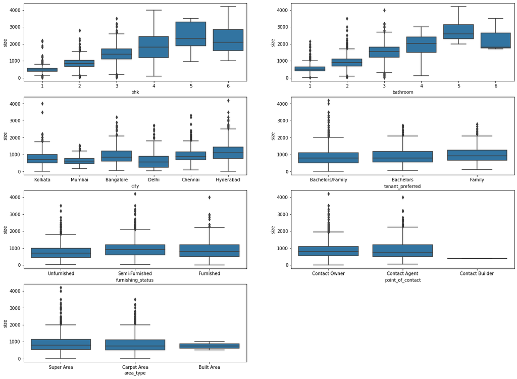

```python
# Plotting boxplot of size and qualitative variables
var_boxplot('size')
```

This validates that the increase in price is due to increase in bhk.

**Finally, let's look at relationships between the three strong norminal Variables of the dataset** **(city, area_type, point of contact)**

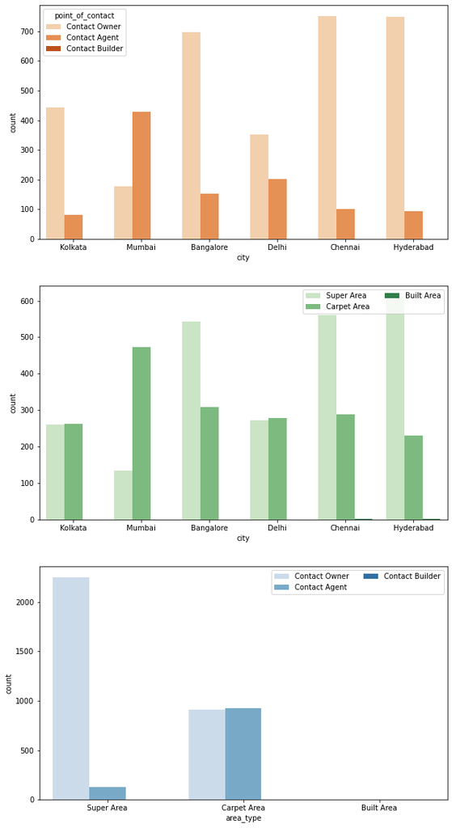

```python
# since there's only three subplots to create, using the full data should be fine.
plt.figure(figsize = [10,20])

# subplot 1: city vs point of contact
plt.subplot(3, 1, 1)
sb.countplot(data = house_rent, x = 'city', hue = 'point_of_contact', palette = 'Oranges')

# subplot 2: city vs. area type
ax = plt.subplot(3, 1, 2)
sb.countplot(data = house_rent, x = 'city', hue = 'area_type', palette = 'Greens')
ax.legend(ncol = 2) # re-arrange legend to reduce overlapping

# subplot 3: area type vs. point of contact
ax = plt.subplot(3, 1, 3)
sb.countplot(data = house_rent, x = 'area_type', hue = 'point_of_contact', palette = 'Blues')
ax.legend(loc = 1, ncol = 2) # re-arrange legend to remove overlapping


plt.show()
```

From our previous understanding, Carpet Area, Contact Agent and Mumbai hav positive relationships wit rent increase. From the there graphs above, the readings shows tha Mumbai has the highest count of houses with Contact Agent and Carpet Area. This is what makes Mumbai to have high rent.

### Talk about some of the relationships you observed in this part of the investigation. How did the feature(s) of interest vary with other features in the dataset?

Rent has a positive relationship with size, even before I transformed the features. An approximately linear relationship exist between rent and size when plotted in a scattered plot, the plot sshowed how increase in rent is proportional to size. We also observed that rent has a relationship between the two categorical variables bhk and bathroom. Rent tends to increase in the same order at which both variables are arranged, this was showen in a boxplot.

### Did you observe any interesting relationships between the other features (not the main feature(s) of interest)?

There are some relationships between rent and the norminal variables (furnishing status, city, point of contact, area type, tenant preferred), each variables has three or more parameters, rent reacts positively to only one of each variable parameter. This shows that the norminal variables also have influence on rent.

## Multivariate Exploration

The main thing I will be looking to explore in this part of the analysis is of the norminal measures of quality play into the relationship between rent and size.(Reason why price increase without an increase in size).

```python
# Create sample data to reduce crowded plot
high_rent = house_rent.sample(300)
```

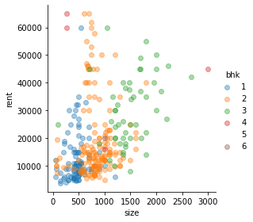

```python
# plotting rent size and bhk, creating a funtion.
def comp_var(var):
    col = var
    g = sb.FacetGrid(data = high_rent, hue = col, height = 4);
    g.map(plt.scatter, 'size', 'rent', alpha=0.4)
    g.add_legend();
comp_var('bhk')
```

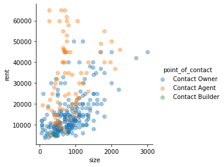

```python
#  plotting point of contact
comp_var('point_of_contact')
```

Most of non-linear point are seen to be Contact Agent. This is one of the factors that contributes to the increase of price without increasing the size.

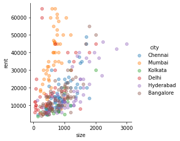

```python
#plotting for variable city
comp_var('city')
```

Houses located in Mumbai also have a non-linear increase when compared to other cities.

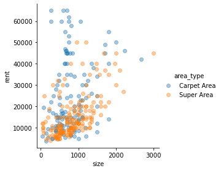

```python
#plotting for variable area type
comp_var('area_type')
```

For Area Type, only Carpet Area shows the non-linear relationship in the distribution.

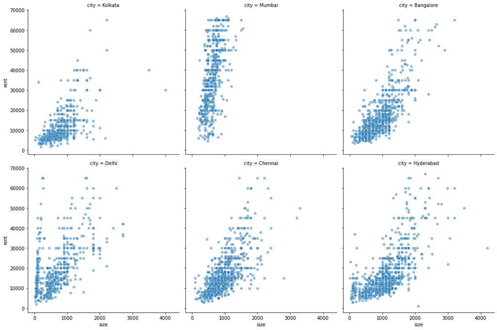

```python
# Plot a relplot of city.
sb.relplot(x='size', y='rent', col='city',
          alpha=.5, palette='muted', data= house_rent, col_wrap=3);
```

Houses in Mumbai are not up to 2000 Squre Feet, but they still have an upward rent increase. Delhi also showed similar characteristics for house with size less than 1000 Square Feet.

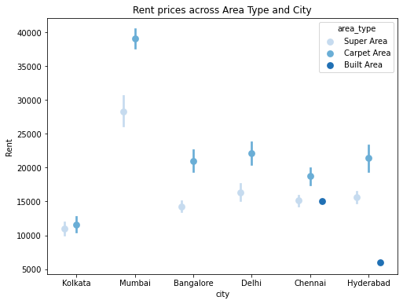

```python
fig = plt.figure(figsize = [8,6])
sb.pointplot(data = house_rent, x = 'city', y = 'rent', hue = 'area_type',
           palette = 'Blues', linestyles = '', dodge = 0.4)
plt.title('Rent prices across Area Type and City')
plt.ylabel('Rent')

plt.show();
```

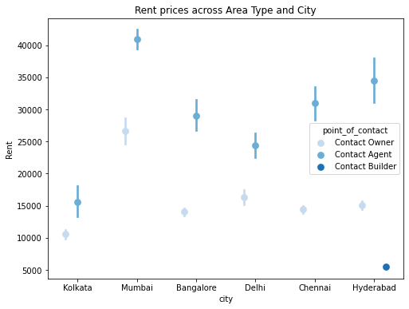

```python
fig = plt.figure(figsize = [8,6])
sb.pointplot(data = house_rent, x = 'city', y = 'rent', hue = 'point_of_contact',
           palette = 'Blues', linestyles = '', dodge = 0.4)
plt.title('Rent prices across Area Type and City')
plt.ylabel('Rent')

plt.show();
```

Rent distribution of point of contact is clear across city values, contact agent clearly comes of as top feature in increasing house rent, rated higher than contact owner and contact builder.

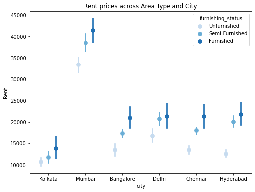

```python
fig = plt.figure(figsize = [8,6])
sb.pointplot(data = house_rent, x = 'city', y = 'rent', hue = 'furnishing_status',
           palette = 'Blues', linestyles = '', dodge = 0.4)
plt.title('Rent prices across Area Type and City')
plt.ylabel('Rent')

plt.show();
```

Just as expected, Furnished building consistently has the highest rent rating across every city with its peak around 41,000 which occurred in Mumbai.

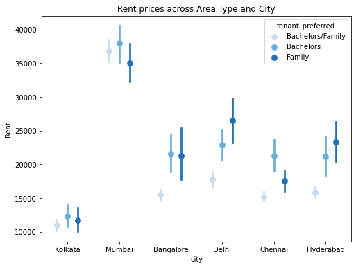

```python
fig = plt.figure(figsize = [8,6])
sb.pointplot(data = house_rent, x = 'city', y = 'rent', hue = 'tenant_preferred',
           palette = 'Blues', linestyles = '', dodge = 0.4)
plt.title('Rent prices across Area Type and City')
plt.ylabel('Rent')

plt.show();
```

The features ratings for point plot graph for Rent prices across tenant_preferred are random. No features in particular maintained consistent increase across the cities.

### Talk about some of the relationships you observed in this part of the investigation. Were there features that strengthened each other in terms of looking at your feature(s) of interest?

Some points showed how the rent increased without the influence of size. We need to find out what features caused this non-linear increase.  
I extended my investigation of Rent against house/apartment size in this section by looking at the impact of Bhk(categorical), City, Point of Contact and Area Type the three norminal quality features, to identify the root cause of what features caused non-linear increase of rent. The multivariate exploration here showed that there indeed is a positive effect of City(mumbai), Point of Contact(contact agent) and Area Type(carpet area) on Rent price. This effect tells us that rent inreases for houses/apartment gotten in Mumbai, acquired through Contact Agent and built in Carpet Areas.

### Were there any interesting or surprising interactions between features?

Looking back on the point plots, it doesn't seem like there's a systematic interaction effect between the three Norminal features. Interestingly, the plot for Rent against Size and city, every city had a linear increase over Size except for Mumbai.

## Conclusions

Carrying out our investigation on what effects increase in rent, Size was the most important feature in predicting Rent just as we expected. However, we discovered some points showed a non-linear increase in rent when plotted on a scatter plot of Rent against Size. Our investigation later revealed to us that other features like Bhk, City, Area Type and Point of Contact has positive reaction to Rent and is responsible for the non-linear increase of Rent. Steps were followed in carrying out our investigation:

Firstly, we used univariate exploration to get the overall distribution of all the variables of the datset. We discovered outliers in a histogram graph of Rent which were deleted from the dataset. Also high volume of dats were located at the lower end of the Quantitative and Categorical variables.

Next, we used bivariate exploration. A scatter plot of both Rent and Size showed Us Rent and Size both have a strong positive linear relationship. However, from the scatter plot there were increase in Rent which were non-linear. Further investigation of the categorical and norminal variables were done and bhk, bathroom, city, point of contact and area type reacted to increase in Rent.

Lastly, multivariate exploration was used to explore analysis of the norminal measures of quality and its relationship between rent and size. Here we discovered features in city, aeea_type and point of contact were the three norminal variables responsible for the non-linear increase of rent.